# Final Project: Optimizing Fantasy Football Lineup

## By: Jayne VanKirk

The objective of this project was to determine what players should make up a nine-player fantasy football team based on their statistics.

### Cleaning Done in Excel

I changed the defense team names so they all have the abbreviation of the team and then 'Defense' to make it easier to match across datasets. For example, the Detroit Lions Defense Team was renamed to 'DET Defense' across all datasets.

```python
# Mounting the drive in order to access the data files
import os
from google.colab import drive
drive.mount('/content/drive')
```

```python
# importing the necessary libraries and solving engines for optimzation problems
import pandas as pd
import pyomo.environ as pe
import matplotlib.pyplot as plt
import numpy as np
import re
!wget -N -q "https://matematica.unipv.it/gualandi/solvers/ipopt-linux64.zip"
!unzip -o -q ipopt-linux64
```

## Reading in the data from the files

```python
# Reading in the salary data as a dataframe
raw_salaries = pd.read_csv('/content/drive/MyDrive/Colab Notebooks/INFO_3440/DataFiles/DKSalaries.csv')
salaries_df = pd.DataFrame(raw_salaries)
salaries_df
```

|  | Position | Name + ID | Name | ID | Roster Position | Salary | Game Info | TeamAbbrev | AvgPointsPerGame |
| --- | --- | --- | --- | --- | --- | --- | --- | --- | --- |
| 0 | RB | Saquon Barkley (37128352) | Saquon Barkley | 37128352 | RB/FLEX | 8600 | DAL@PHI 12/29/2024 01:00PM ET | PHI | 24.49 |
| 1 | QB | Josh Allen (37128254) | Josh Allen | 37128254 | QB | 8500 | NYJ@BUF 12/29/2024 01:00PM ET | BUF | 24.87 |
| 2 | RB | Jahmyr Gibbs (37128354) | Jahmyr Gibbs | 37128354 | RB/FLEX | 8500 | DET@SF 12/30/2024 08:15PM ET | DET | 20.04 |
| 3 | WR | Ja'Marr Chase (37128674) | Ja'Marr Chase | 37128674 | WR/FLEX | 8400 | DEN@CIN 12/28/2024 04:30PM ET | CIN | 24.68 |
| 4 | WR | Justin Jefferson (37128676) | Justin Jefferson | 37128676 | WR/FLEX | 8300 | GB@MIN 12/29/2024 04:25PM ET | MIN | 20.46 |
| ... | ... | ... | ... | ... | ... | ... | ... | ... | ... |
| 704 | DST | Patriots (37129540) | NE Defense | 37129540 | DST | 2400 | LAC@NE 12/28/2024 01:00PM ET | NE | 4.40 |
| 705 | DST | 49ers (37129543) | SF Defense | 37129543 | DST | 2300 | DET@SF 12/30/2024 08:15PM ET | SF | 5.87 |
| 706 | DST | Giants (37129542) | NYG Defense | 37129542 | DST | 2300 | IND@NYG 12/29/2024 01:00PM ET | NYG | 5.00 |
| 707 | DST | Panthers (37129544) | CAR Defense | 37129544 | DST | 2200 | CAR@TB 12/29/2024 01:00PM ET | CAR | 2.93 |
| 708 | DST | Jets (37129545) | NYJ Defense | 37129545 | DST | 2100 | NYJ@BUF 12/29/2024 01:00PM ET | NYJ | 5.73 |

709 rows × 9 columns

```python
# Reading in the actual game data
raw_week17 = pd.read_csv('/content/drive/MyDrive/Colab Notebooks/INFO_3440/DataFiles/NFLWeek17Stats.csv')
week17_df = pd.DataFrame(raw_week17)
# Renaming the Player column with Name to match the salaries dataset
week17_df.rename(columns={'Player': 'Name'}, inplace=True)
week17_df
```

|  | Name | Tm | Pass Cmp | Pass Att | Pass Yds | Pass TD | Pass Int | Pass Sack | Pass Sack Yds | Pass Long Complete | ... | Ttl Pts Allowed | Safety | Blocked Kicks | Sack | Interception | Fumble Recovery | Punt/Kickoff/FG Return for TD | Interception Return TD | Fumble Recovery TD | Blocked Punt or FG Return TD |
| --- | --- | --- | --- | --- | --- | --- | --- | --- | --- | --- | --- | --- | --- | --- | --- | --- | --- | --- | --- | --- | --- |
| 0 | Kyler Murray | ARI | 33 | 48 | 321 | 1 | 2 | 4 | 38 | 34 | ... | 0 | 0 | 0 | 0 | 0 | 0 | 0 | 0 | 0 | 0 |
| 1 | Michael Carter | ARI | 0 | 0 | 0 | 0 | 0 | 0 | 0 | 0 | ... | 0 | 0 | 0 | 0 | 0 | 0 | 0 | 0 | 0 | 0 |
| 2 | Michael Wilson | ARI | 0 | 0 | 0 | 0 | 0 | 0 | 0 | 0 | ... | 0 | 0 | 0 | 0 | 0 | 0 | 0 | 0 | 0 | 0 |
| 3 | James Conner | ARI | 0 | 0 | 0 | 0 | 0 | 0 | 0 | 0 | ... | 0 | 0 | 0 | 0 | 0 | 0 | 0 | 0 | 0 | 0 |
| 4 | Trey McBride | ARI | 0 | 0 | 0 | 0 | 0 | 0 | 0 | 0 | ... | 0 | 0 | 0 | 0 | 0 | 0 | 0 | 0 | 0 | 0 |
| ... | ... | ... | ... | ... | ... | ... | ... | ... | ... | ... | ... | ... | ... | ... | ... | ... | ... | ... | ... | ... | ... |
| 347 | BUF Defense | BUF | 0 | 0 | 0 | 0 | 0 | 0 | 0 | 0 | ... | 14 | 1 | 0 | 4 | 2 | 1 | 0 | 0 | 0 | 0 |
| 348 | SEA Defense | SEA | 0 | 0 | 0 | 0 | 0 | 0 | 0 | 0 | ... | 3 | 0 | 0 | 7 | 1 | 2 | 0 | 0 | 0 | 0 |
| 349 | CHI Defense | CHI | 0 | 0 | 0 | 0 | 0 | 0 | 0 | 0 | ... | 6 | 0 | 0 | 3 | 0 | 3 | 0 | 0 | 0 | 0 |
| 350 | TEN Defense | TEN | 0 | 0 | 0 | 0 | 0 | 0 | 0 | 0 | ... | 20 | 0 | 0 | 2 | 0 | 2 | 0 | 0 | 0 | 0 |
| 351 | JAX Defense | JAX | 0 | 0 | 0 | 0 | 0 | 0 | 0 | 0 | ... | 13 | 0 | 0 | 3 | 1 | 0 | 0 | 0 | 0 | 0 |

352 rows × 32 columns

```python
# Reading in the historical data
raw_pass = pd.read_excel('/content/drive/MyDrive/Colab Notebooks/INFO_3440/DataFiles/NFL2024SeasonStats.xlsx', sheet_name = 'PassStats')
pass_df = pd.DataFrame(raw_pass)
raw_rush = pd.read_excel('/content/drive/MyDrive/Colab Notebooks/INFO_3440/DataFiles/NFL2024SeasonStats.xlsx', sheet_name = 'RushStats')
rush_df = pd.DataFrame(raw_rush)
raw_rcv = pd.read_excel('/content/drive/MyDrive/Colab Notebooks/INFO_3440/DataFiles/NFL2024SeasonStats.xlsx', sheet_name = 'RcvStats')
rcv_df = pd.DataFrame(raw_rcv)
raw_def = pd.read_excel('/content/drive/MyDrive/Colab Notebooks/INFO_3440/DataFiles/NFL2024SeasonStats.xlsx', sheet_name = 'DefStats')
def_df = pd.DataFrame(raw_def)
```

```python
# Renaming the Player column with Name to match the salaries dataset
pass_df.rename(columns={'Player': 'Name'}, inplace=True)
rush_df.rename(columns={'Player': 'Name'}, inplace=True)
rcv_df.rename(columns={'Player': 'Name'}, inplace=True)
```

```python
# Removed generational suffixes since it is inconsistent across datasets
week17_df['Name'] = week17_df['Name'].str.replace(r'(\s*(Jr|Sr|II|III|IV|V|VI|VII|VIII|IX|X)\.?)$', '', regex=True)
salaries_df['Name'] = salaries_df['Name'].str.replace(r'(\s*(Jr|Sr|II|III|IV|V|VI|VII|VIII|IX|X)\.?)$', '', regex=True)
pass_df['Name'] = pass_df['Name'].str.replace(r'(\s*(Jr|Sr|II|III|IV|V|VI|VII|VIII|IX|X)\.?)$', '', regex=True)
rush_df['Name'] = rush_df['Name'].str.replace(r'(\s*(Jr|Sr|II|III|IV|V|VI|VII|VIII|IX|X)\.?)$', '', regex=True)
rcv_df['Name'] = rcv_df['Name'].str.replace(r'(\s*(Jr|Sr|II|III|IV|V|VI|VII|VIII|IX|X)\.?)$', '', regex=True)
```

```python
# Creating a dataframe to hold the fantasy points that are assigned to each category
fp_df = pd.DataFrame({
    "Category": [
        "Pass TD", "Pass Yds", "Pass Yds (Greater than 300)", "Pass Int",
        "Rush TD", "Rush Yds", "Rush Yds (Greater than 100)", "Rcv TD",
        "Rcv Yds", "Rcv Yds (Greater than 100)", "Rec",
        "Punt/Kickoff/FG Return for TD", "FL", "2Pt Conversions",
        "Fumble Recovery TD", "Sack", "Interception", "Fumble Recovery",
        "Blocked Punt or FG Return TD", "Interception Return TD",
        "Safety", "Blocked Kicks", "Ttl Pts Allowed (0)",
        "Ttl Pts Allowed (1-6)", "Ttl Pts Allowed (7-13)",
        "Ttl Pts Allowed (14-20)", "Ttl Pts Allowed (21-27)",
        "Ttl Pts Allowed (28-34)", "Ttl Pts Allowed (35+)" ],
    "Points": [
        4, 0.04, 3, -1, 6, 0.1, 3, 6, 0.1, 3, 1, 6, -1, 2, 6, 1, 2, 2,
        6, 6, 2, 2, 10, 7, 4, 1, 0, -1, -4]})
fp_df
```

|  | Category | Points |
| --- | --- | --- |
| 0 | Pass TD | 4.00 |
| 1 | Pass Yds | 0.04 |
| 2 | Pass Yds (Greater than 300) | 3.00 |
| 3 | Pass Int | -1.00 |
| 4 | Rush TD | 6.00 |
| 5 | Rush Yds | 0.10 |
| 6 | Rush Yds (Greater than 100) | 3.00 |
| 7 | Rcv TD | 6.00 |
| 8 | Rcv Yds | 0.10 |
| 9 | Rcv Yds (Greater than 100) | 3.00 |
| 10 | Rec | 1.00 |
| 11 | Punt/Kickoff/FG Return for TD | 6.00 |
| 12 | FL | -1.00 |
| 13 | 2Pt Conversions | 2.00 |
| 14 | Fumble Recovery TD | 6.00 |
| 15 | Sack | 1.00 |
| 16 | Interception | 2.00 |
| 17 | Fumble Recovery | 2.00 |
| 18 | Blocked Punt or FG Return TD | 6.00 |
| 19 | Interception Return TD | 6.00 |
| 20 | Safety | 2.00 |
| 21 | Blocked Kicks | 2.00 |
| 22 | Ttl Pts Allowed (0) | 10.00 |
| 23 | Ttl Pts Allowed (1-6) | 7.00 |
| 24 | Ttl Pts Allowed (7-13) | 4.00 |
| 25 | Ttl Pts Allowed (14-20) | 1.00 |
| 26 | Ttl Pts Allowed (21-27) | 0.00 |
| 27 | Ttl Pts Allowed (28-34) | -1.00 |
| 28 | Ttl Pts Allowed (35+) | -4.00 |

```python
# Getting the names of players that only appear in both of the salaries data set and the week17 dataset
salaries_names = set(salaries_df['Name'].str.strip())  # Strip any extra spaces or newline characters
week17_names = set(week17_df['Name'].str.strip())  # Same for week17_df

# Find the intersection of both sets
valid_names = salaries_names.intersection(week17_names)

# Filter the players list to only include valid names (those in both datasets)
player_names = [player for player in valid_names]

# Printing the number of players the optimization problem has to choose from
print(f" Number of players: {len(player_names)}")
```

```
 Number of players: 291
```

## Calculating Fantasy Points

```python
# Computing the fantasy points for each player in the week 17 games

# List to hold total points of each player
players_fantasy_points = []
# Looping through each player
for name in player_names:
  total_points = 0
  # Looping through each category for fantasy points
  for category in fp_df['Category']:
    # if statements for all of the categories that have special conditions
    if category == 'Pass Yds (Greater than 300)':
      # gets the passing yards for that player
      pass_yds = week17_df.loc[week17_df['Name'] == name, 'Pass Yds']
      # checks if the yards are greater than 3000
      if pass_yds.iloc[0] >= 300:
        # if so it adds the points to the players fantasy score, otherwise it adds nothing
        total_points += fp_df.loc[fp_df['Category'] == category, 'Points'].iloc[0]
    elif category == 'Rush Yds (Greater than 100)':
      rush_yds = week17_df.loc[week17_df['Name'] == name, 'Rush Yds']
      if rush_yds.iloc[0] >= 100:
        total_points += fp_df.loc[fp_df['Category'] == category, 'Points'].iloc[0]
    elif category == 'Rcv Yds (Greater than 100)':
      rcv_yds = week17_df.loc[week17_df['Name'] == name, 'Rcv Yds']
      if rcv_yds.iloc[0] >= 100:
        total_points += fp_df.loc[fp_df['Category'] == category, 'Points'].iloc[0]
    elif category == 'Ttl Pts Allowed (0)':
      allowed_points = week17_df.loc[week17_df['Name'] == name, 'Ttl Pts Allowed']
      if allowed_points.iloc[0] == 0:
        total_points += fp_df.loc[fp_df['Category'] == category, 'Points'].iloc[0]
    elif category == 'Ttl Pts Allowed (1-6)':
      allowed_points = week17_df.loc[week17_df['Name'] == name, 'Ttl Pts Allowed']
      if allowed_points.iloc[0] >= 1 and allowed_points.iloc[0] <= 6:
        total_points += fp_df.loc[fp_df['Category'] == category, 'Points'].iloc[0]
    elif category == 'Ttl Pts Allowed (7-13)':
      allowed_points = week17_df.loc[week17_df['Name'] == name, 'Ttl Pts Allowed']
      if allowed_points.iloc[0] >= 7 and allowed_points.iloc[0] <= 13:
        total_points += fp_df.loc[fp_df['Category'] == category, 'Points'].iloc[0]
    elif category == 'Ttl Pts Allowed (14-20)':
      allowed_points = week17_df.loc[week17_df['Name'] == name, 'Ttl Pts Allowed']
      if allowed_points.iloc[0] >= 14 and allowed_points.iloc[0] <= 20:
        total_points += fp_df.loc[fp_df['Category'] == category, 'Points'].iloc[0]
    elif category == 'Ttl Pts Allowed (21-27)':
      allowed_points = week17_df.loc[week17_df['Name'] == name, 'Ttl Pts Allowed']
      if allowed_points.iloc[0] >= 21 and allowed_points.iloc[0] <= 27:
        total_points += fp_df.loc[fp_df['Category'] == category, 'Points'].iloc[0]
    elif category == 'Ttl Pts Allowed (28-34)':
      allowed_points = week17_df.loc[week17_df['Name'] == name, 'Ttl Pts Allowed']
      if allowed_points.iloc[0] >= 28 and allowed_points.iloc[0] <= 34:
        total_points += fp_df.loc[fp_df['Category'] == category, 'Points'].iloc[0]
    elif category == 'Ttl Pts Allowed (35+)':
      allowed_points = week17_df.loc[week17_df['Name'] == name, 'Ttl Pts Allowed']
      if allowed_points.iloc[0] >= 35:
        total_points += fp_df.loc[fp_df['Category'] == category, 'Points'].iloc[0]
    # For all the other points, they are calculated by multiplying the occurences by the fantasy point values
    else:
      total_points += fp_df.loc[fp_df['Category'] == category, 'Points'].iloc[0] * week17_df.loc[week17_df['Name'] == name, category].iloc[0]
  # Points are added to the week17_df for that player once all the categories' points have been added
  week17_df.loc[week17_df['Name'] == name, 'Calculated Fantasy Points'] = total_points
```

## Problem 1: Selecting the optimal lineup based on how the players performed during their actual games.

Objective: Maximize total fantasy points

Decision Variables:

- Players (binary- if they were chosen yes/no)
- Games (binary- if players chosen played in those games yes/no)

Constraints:

- Exactly 9 players
- Total salary of players cannot exceed 50,000
- Players need to be from at least two different games
- Positions needed: 1 QB, 2RBs, 3 WR, 1 TE, 1 DST, and 1 FLEX position (can be a RB, WR, or TE)

```python
# Creating a model to determine what players we should choose based on their week 17 stats
model_p1 = pe.ConcreteModel()
# Binary decision variables for each player
model_p1.players = pe.Var(player_names, domain = pe.Binary)

# Extract unique games from the salary df
game_list = salaries_df['Game Info'].unique()

# Create binary decision variables for games
model_p1.game_selected = pe.Var(game_list, domain=pe.Binary)

# The objective is to maximize the fantasy points
# This loops through all players and based on if they were chosen or not, their calculated fantasy points
# are added to the total
model_p1.obj = pe.Objective(
    expr = sum(
        week17_df.loc[week17_df['Name'] == name, 'Calculated Fantasy Points'].values[0]
        * model_p1.players[name]
        for name in player_names),
    sense = pe.maximize)
```

```python
# Adding Constraints
# 9 Players Constraint
model_p1.players_count = pe.Constraint(expr = sum([model_p1.players[name] for name in player_names]) == 9)

# Salary 50,000 Constraint
model_p1.salary_cap = pe.Constraint(expr=sum(salaries_df.loc[salaries_df['Name'] == name, 'Salary'].values[0] * model_p1.players[name]
                                             for name in player_names) <= 50000)
```

```python
# Players need to come from at least two different games constraint
model_p1.game_constraint = pe.Constraint(expr=sum([model_p1.game_selected[game] for game in game_list]) >= 2)
```

```python
# Constraint for 1 Quarterback
model_p1.qb_constraint = pe.Constraint(expr=sum([model_p1.players[name] for name in player_names if salaries_df.loc[salaries_df['Name'] == name, 'Position'].values[0] == 'QB']) == 1)
```

```python
# Constraint for 2 Running Backs
model_p1.rb_constraint = pe.Constraint(expr=sum([model_p1.players[name] for name in player_names if salaries_df.loc[salaries_df['Name'] == name, 'Position'].values[0] == 'RB']) >= 2)
```

```python
# Constraint for 3 Wide Recievers
model_p1.wr_constraint = pe.Constraint(expr=sum([model_p1.players[name] for name in player_names if salaries_df.loc[salaries_df['Name'] == name, 'Position'].values[0] == 'WR']) >= 3)
```

```python
# Constraint for 1 Tight End
model_p1.te_constraint = pe.Constraint(expr=sum([model_p1.players[name] for name in player_names if salaries_df.loc[salaries_df['Name'] == name, 'Position'].values[0] == 'TE']) >= 1)
```

```python
# Constraint for 1 Defense/ Special Team
model_p1.dst_constraint = pe.Constraint(expr=sum([model_p1.players[name] for name in player_names if salaries_df.loc[salaries_df['Name'] == name, 'Position'].values[0] == 'DST']) == 1)

# Constraint for 1 Flexible Position is assumed by making the constraint for nine players, and the QB and DST positions exactly 1
```

```python
# Solving the model and checking if there is an optimal solution
opt = pe.SolverFactory('appsi_highs')
result = opt.solve(model_p1)
print(result.solver.status, result.solver.termination_condition)
```

```
ok optimal
```

```python
# Print the selected players
selected_players = [player for player in player_names if pe.value(model_p1.players[player]) == 1]
print("Selected Players:", selected_players)

# Calculates and print the total fantasy points for the selected players
total_fantasy_points = sum(
    week17_df.loc[week17_df['Name'] == name, 'Calculated Fantasy Points'].values[0]
    * pe.value(model_p1.players[name])  # Only add fantasy points for selected players
    for name in player_names
)

# Calculates the total salary for the selected players
total_salary = sum(
    salaries_df.loc[salaries_df['Name'] == name, 'Salary'].values[0]
    * pe.value(model_p1.players[name])
     for name in player_names)

# Creating a dictionary to hold the total fantasy points from each model
model_fantasy_points = {
    'Model 1: Week 17 Actuals': total_fantasy_points
}

print("Total Fantasy Points:", round(total_fantasy_points,2))
print("Total Salary: ", round(total_salary,2))
```

```
Selected Players: ['Drew Lock', 'PHI Defense', 'Jonathan Taylor', 'Ricky Pearsall', 'Tee Higgins', 'Marvin Mims', 'Malik Nabers']
Total Fantasy Points: 372.56
Total Salary:  49800.0
```

After running the optimization model, a solution was able to be found. To create the best fantasy team for week 17, the players should consist of Drew Lock, PHI Defense, Jonathan Taylor, Ricky Pearsall, Tee Higgins, Marvin Mims, and Malik Nabers. This lineup will result in 372.56 fantasy points and 49,800 total salary.

## Problem 2a: Naive strategy of selecting players based on average daily points

Objective: Maximize total average points per game

Decision Variables:

- Players (binary- if they were chosen yes/no)
- Games (binary- if players chosen played in those games yes/no)

Constraints:

- Exactly 9 players
- Total salary of players cannot exceed 50,000
- Players need to be from at least two different games
- Positions needed: 1 QB, 2RBs, 3 WR, 1 TE, 1 DST, and 1 FLEX position (can be a RB, WR, or TE)

```python
# Creating a model based on maximizing the total average points (the naive strategy)
model_naive = pe.ConcreteModel()
# Binary decision variables for each player
model_naive.players = pe.Var(player_names, domain = pe.Binary)

# Extract unique games from the salary df
game_list = salaries_df['Game Info'].unique()

# Create binary decision variables for games
model_naive.game_selected = pe.Var(game_list, domain=pe.Binary)

# The objective is to maximize the Average Points per Game
# This loops through all players and based on if they were chosen or not, their calculated AvgPointsPerGame
# are added to the total
model_naive.obj = pe.Objective(
    expr = sum(
        salaries_df.loc[salaries_df['Name'] == name, 'AvgPointsPerGame'].values[0]
        * model_naive.players[name]
        for name in player_names),
    sense = pe.maximize)
```

```python
# Same constraints as before

# 9 Players Constraint
model_naive.players_count = pe.Constraint(expr = sum([model_naive.players[name] for name in player_names]) == 9)

# Salary 50,000 Constraint
model_naive.salary_cap = pe.Constraint(expr=sum(salaries_df.loc[salaries_df['Name'] == name, 'Salary'].values[0] * model_naive.players[name]
                                             for name in player_names) <= 50000)

# Players need to come from at least two different games constraint
model_naive.game_constraint = pe.Constraint(expr=sum([model_naive.game_selected[game] for game in game_list]) >= 2)

# Constraint for 1 Quarterback
model_naive.qb_constraint = pe.Constraint(expr=sum([model_naive.players[name] for name in player_names if salaries_df.loc[salaries_df['Name'] == name, 'Position'].values[0] == 'QB']) == 1)

# Constraint for 2 Running Backs
model_naive.rb_constraint = pe.Constraint(expr=sum([model_naive.players[name] for name in player_names if salaries_df.loc[salaries_df['Name'] == name, 'Position'].values[0] == 'RB']) >= 2)

# Constraint for 3 Wide Recievers
model_naive.wr_constraint = pe.Constraint(expr=sum([model_naive.players[name] for name in player_names if salaries_df.loc[salaries_df['Name'] == name, 'Position'].values[0] == 'WR']) >= 3)

# Constraint for 1 Tight End
model_naive.te_constraint = pe.Constraint(expr=sum([model_naive.players[name] for name in player_names if salaries_df.loc[salaries_df['Name'] == name, 'Position'].values[0] == 'TE']) >= 1)

# Constraint for 1 Defense/ Special Team
model_naive.dst_constraint = pe.Constraint(expr=sum([model_naive.players[name] for name in player_names if salaries_df.loc[salaries_df['Name'] == name, 'Position'].values[0] == 'DST']) == 1)

# Constraint for 1 Flexible Position is assumed by making the constraint for nine players, and the QB and DST positions exactly 1
```

```python
# Solving the model and checking if there is an optimal solution
opt = pe.SolverFactory('appsi_highs')
result = opt.solve(model_naive)
print(result.solver.status, result.solver.termination_condition)
```

```
ok optimal
```

```python
# Print the selected players
# This solver engine sometimes had some floating point preciison errors, so the players picked weren't all exactly 1.0
# Some were .999 for example
selected_players = [player for player in player_names if pe.value(model_naive.players[player]) >0.9]
print("Selected Players:", selected_players)

# Calculates and print the total fantasy points for the selected players
total_fantasy_points = sum(
    week17_df.loc[week17_df['Name'] == name, 'Calculated Fantasy Points'].values[0]
    * pe.value(model_naive.players[name])  # Only add fantasy points for selected players
    for name in player_names)

# Calculates the total salary for the selected players
total_salary = sum(
    salaries_df.loc[salaries_df['Name'] == name, 'Salary'].values[0]
    * pe.value(model_naive.players[name])
     for name in player_names)

print("Total Fantasy Points:", round(total_fantasy_points,2))
# printing the maximum total average points given the constraints
obj_val = model_naive.obj.expr()

# Adding the total fantasy points to the dictionary
model_fantasy_points['Model 2a: Naive Strategy'] = total_fantasy_points

print("Maximum Total Average Points:", obj_val)
print("Total Salary: ", round(total_salary,2))
```

```
Selected Players: ["Ja'Marr Chase", 'Tucker Kraft', 'Allen Lazard', 'Josh Downs', 'Saquon Barkley', 'DEN Defense', 'Joe Burrow', 'Michael Carter', 'George Kittle']
Total Fantasy Points: 220.78
Maximum Total Average Points: 144.69
Total Salary:  49800.0
```

After running the optimization model using the naive strategy of selecting players based on their average points per game, it was able to come to a solution. The model found that the players that should be selected are Ja'Marr Chase, Tucker Kraft, Allen Lazard, Josh Downs, Saquon Barkley, DEN Defense, Joe Burrow, Michael Carter, and George Kittle. This would result in 220.78 total fantasy points, 144.69 total average points per game, and 49,800 salary for all nine players.

## Original Problem 2b: Creating a Custom Strategy for Choosing Players

I do not watch much football so I went on Google to find stats for each position. These are the sources I pulled inspiration from: https://www.reddit.com/r/fantasyfootball/comments/cb1kv8/predictive_fantasy_stats_simplified_a_quick_guide/ https://www.nbcsports.com/fantasy/football/news/2024-fantasy-football-d-st-draft-strategy

Objective: Maximize the following stats based on the player type:

- QB: Cmp
- RBs: Att
- WRs and TEs: AY/A
- DST: Pass Int

Decision Variables:

- Players (binary- if they were chosen yes/no)
- Games (binary- if players chosen played in those games yes/no)

Constraints:

- Exactly 9 players
- Total salary of players cannot exceed 50,000
- Players need to be from at least two different games
- Positions needed: 1 QB, 2RBs, 3 WR, 1 TE, 1 DST, and 1 FLEX position (can be a RB, WR, or TE)

```python
# Creating a model based on maximizing various stats depending on position
model_custom = pe.ConcreteModel()
# Binary decision variables for each player
model_custom.players = pe.Var(player_names, domain = pe.Binary)

# Extract unique games from the salary df
game_list = salaries_df['Game Info'].unique()

# Create binary decision variables for games
model_custom.game_selected = pe.Var(game_list, domain=pe.Binary)

# Objective is to maximize stats based on the various player types
model_custom.obj = pe.Objective(
    expr = sum(
        # Cmp stat for selected QBs
        (pass_df.loc[pass_df['Name'] == player, 'Cmp'].values[0] * model_custom.players[player]
         if salaries_df[salaries_df['Name'] == player]['Position'].values[0] == 'QB' else 0) +
        # Att stat for selected RBs
        (rush_df.loc[rush_df['Name'] == player, 'Att'].values[0] * model_custom.players[player]
         if salaries_df[salaries_df['Name'] == player]['Position'].values[0] == 'RB' else 0) +
        # AY/A stat for selected WRs and TEs
        (pass_df.loc[pass_df['Name'] == player, 'AY/A'].values[0] * model_custom.players[player]
         if salaries_df[salaries_df['Name'] == player]['Position'].values[0] == ['WR'] else 0 ) +
        (pass_df.loc[pass_df['Name'] == player, 'AY/A'].values[0] * model_custom.players[player]
         if salaries_df[salaries_df['Name'] == player]['Position'].values[0] == ['TE'] else 0) +
        # Pass Int stat for DST
        (def_df.loc[def_df['Name'] == player, 'Pass Int'].values[0] * model_custom.players[player]
         if salaries_df[salaries_df['Name'] == player]['Position'].values[0] == 'DST' else 0)
        for player in player_names),
    sense = pe.maximize)
```

```python
# Constraints the same still
# 9 Players Constraint
model_custom.players_count = pe.Constraint(expr = sum([model_custom.players[name] for name in player_names]) == 9)

# Salary 50,000 Constraint
model_custom.salary_cap = pe.Constraint(expr=sum(salaries_df.loc[salaries_df['Name'] == name, 'Salary'].values[0] * model_custom.players[name]
                                             for name in player_names) <= 50000)

# Players need to come from at least two different games constraint
model_custom.game_constraint = pe.Constraint(expr=sum([model_custom.game_selected[game] for game in game_list]) >= 2)

# Constraint for 1 Quarterback
model_custom.qb_constraint = pe.Constraint(expr=sum([model_custom.players[name] for name in player_names if salaries_df.loc[salaries_df['Name'] == name, 'Position'].values[0] == 'QB']) == 1)

# Constraint for 2 Running Backs
model_custom.rb_constraint = pe.Constraint(expr=sum([model_custom.players[name] for name in player_names if salaries_df.loc[salaries_df['Name'] == name, 'Position'].values[0] == 'RB']) >= 2)

# Constraint for 3 Wide Recievers
model_custom.wr_constraint = pe.Constraint(expr=sum([model_custom.players[name] for name in player_names if salaries_df.loc[salaries_df['Name'] == name, 'Position'].values[0] == 'WR']) >= 3)

# Constraint for 1 Tight End
model_custom.te_constraint = pe.Constraint(expr=sum([model_custom.players[name] for name in player_names if salaries_df.loc[salaries_df['Name'] == name, 'Position'].values[0] == 'TE']) >= 1)

# Constraint for 1 Defense/ Special Team
model_custom.dst_constraint = pe.Constraint(expr=sum([model_custom.players[name] for name in player_names if salaries_df.loc[salaries_df['Name'] == name, 'Position'].values[0] == 'DST']) == 1)

# Constraint for 1 Flexible Position is assumed by making the constraint for nine players, and the QB and DST positions exactly 1
```

```python
# Solving the model and checking if there is an optimal solution
opt = pe.SolverFactory('appsi_highs')
result = opt.solve(model_custom)
print(result.solver.status, result.solver.termination_condition)
```

```
ok optimal
```

```python
# Print the selected players
# This solver engine sometimes had some floating point preciison errors, so the players picked weren't all exactly 1.0
# Some were .999 for example
selected_players = [player for player in player_names if pe.value(model_custom.players[player]) >0.9]
print("Selected Players:", selected_players)

# Calculates the total fantasy points for the selected players
total_fantasy_points = sum(
    week17_df.loc[week17_df['Name'] == name, 'Calculated Fantasy Points'].values[0]
    * pe.value(model_custom.players[name])  # Only add fantasy points for selected players
    for name in player_names)

# Calculates the total average points for the selected players to compare to the naive method
total_average_points = sum(
    salaries_df.loc[salaries_df['Name'] == name, 'AvgPointsPerGame'].values[0]
    * pe.value(model_custom.players[name])  # Only add fantasy points for selected players
    for name in player_names
)

# Calculates the total salary for the selected players
total_salary = sum(
    salaries_df.loc[salaries_df['Name'] == name, 'Salary'].values[0]
    * pe.value(model_custom.players[name])
     for name in player_names)

# Adding the total fantasy points to the dictionary
model_fantasy_points['Model 2b: Original Custom Strategy'] = total_fantasy_points

print("Total Fantasy Points:", round(total_fantasy_points,2))
print("Total Average Points:", round(total_average_points,2))
print("Total Salary:", round(total_salary,2))
```

```
Selected Players: ['Saquon Barkley', 'Joe Burrow', 'Kyren Williams', 'Bijan Robinson', 'MIN Defense', 'Jonathan Mingo', 'Malik Heath', 'Devin Duvernay', 'Davis Allen']
Total Fantasy Points: 200.78
Total Average Points: 101.72
Total Salary: 46300.0
```

After running the model using my custom strategy of focusing on different stats based on the player type, the model was able to find a solution. The model chose Saquon Barkley, Joe Burrow, Kyren Williams, Bijan Robinson, MIN Defense, Jonathan Mingo, Malik Heath, Devin Duvernay, and Davis Allen for the fantasy team lineup. These players would result in 200.78 fantasy points, 101.72 total average points, and 46,300 total salary.

## Revised Problem 2b: Changing the objective function based on GAI tool

Objective: After consulting Gemini to do create a custom strategy for finding the optimal lineup, it was able to find a lineup that was better than the naive model of just looking at the average points per game. Therefore, I decided to adapt its strategy for solving Problem 2b.

Objective: Maximizes the calculated average fantasy points based on historical data

Decision Variables:

- Players (binary- if they were chosen yes/no)
- Games (binary- if players chosen played in those games yes/no)

Constraints:

- Exactly 9 players
- Total salary of players cannot exceed 50,000
- Players need to be from at least two different games
- Positions needed: 1 QB, 2RBs, 3 WR, 1 TE, 1 DST, and 1 FLEX position (can be a RB, WR, or TE)

```python
# First calculating the fantasy points based on historical data
# Function to calculate average fantasy points across stats
def calculate_avg_fantasy_points(player_name):
    """Calculates the average fantasy points for a player using historical data."""
    # variable to hold total points for the player
    total_points = 0
    # variable to hold number of times the player shows up in a stat category: pass, rush, and rcv
    num_stats = 0

    # Get passing stats for the player and calculate fantasy points
    player_pass_df = pass_df[pass_df['Name'] == player_name]
    # goes through all the passing stats for that player
    for index, row in player_pass_df.iterrows():
        # calculates the points that should be added based on TDs, Yds, and if Yds was greater than 300 but subtracts any interceptions
        total_points += row['TD'] * 4 + row['Yds'] * 0.04 + (row['Yds'] > 300) * 3 - row['Int']
        num_stats += 1

    # Get rushing stats for the player and calculate fantasy points
    player_rush_df = rush_df[rush_df['Name'] == player_name]
    # goes through all the rushing stats for that player
    for index, row in player_rush_df.iterrows():
        # calculates the points that should be added based on Tds, Yds, and if Yds was greater than 100
        total_points += row['TD'] * 6 + row['Yds'] * 0.1 + (row['Yds'] > 100) * 3
        num_stats += 1

    # Get receiving stats for the player and calculate fantasy points
    player_rcv_df = rcv_df[rcv_df['Name'] == player_name]
    # goes through all the recieving stats for that player
    for index, row in player_rcv_df.iterrows():
        # calculates the points that should be added based on Tds, Yds, and if Yds was greater than 100, and Recs
        total_points += row['TD'] * 6 + row['Yds'] * 0.1 + (row['Yds'] > 100) * 3 + row['Rec']
        num_stats += 1

    # If it was able to find stats for that player it divides the total points by the number of stats it was able to find the player in
    if num_stats > 0:
        return total_points / num_stats
    else:
        return 0  # Return 0 if no historical data is found for the player
```

```python
# adding the calculated fantasy points based on historical data to the week17 dataframe
week17_df['HistoricalFantasyPoints'] = week17_df['Name'].apply(calculate_avg_fantasy_points)
```

```python
# Creating a model based on maximizing various stats depending on position
model_custom = pe.ConcreteModel()
# Binary decision variables for each player
model_custom.players = pe.Var(player_names, domain = pe.Binary)

# Extract unique games from the salary df
game_list = salaries_df['Game Info'].unique()

# Create binary decision variables for games
model_custom.game_selected = pe.Var(game_list, domain=pe.Binary)

# Objective is to maximize stats based on the various player types
model_custom.obj = pe.Objective(
    expr = sum(
        week17_df.loc[week17_df['Name'] == name, 'HistoricalFantasyPoints'].values[0]
        * model_custom.players[name]
        for name in player_names),
    sense = pe.maximize)
```

```python
# Constraints the same still
# 9 Players Constraint
model_custom.players_count = pe.Constraint(expr = sum([model_custom.players[name] for name in player_names]) == 9)

# Salary 50,000 Constraint
model_custom.salary_cap = pe.Constraint(expr=sum(salaries_df.loc[salaries_df['Name'] == name, 'Salary'].values[0] * model_custom.players[name]
                                             for name in player_names) <= 50000)

# Players need to come from at least two different games constraint
model_custom.game_constraint = pe.Constraint(expr=sum([model_custom.game_selected[game] for game in game_list]) >= 2)

# Constraint for 1 Quarterback
model_custom.qb_constraint = pe.Constraint(expr=sum([model_custom.players[name] for name in player_names if salaries_df.loc[salaries_df['Name'] == name, 'Position'].values[0] == 'QB']) == 1)

# Constraint for 2 Running Backs
model_custom.rb_constraint = pe.Constraint(expr=sum([model_custom.players[name] for name in player_names if salaries_df.loc[salaries_df['Name'] == name, 'Position'].values[0] == 'RB']) >= 2)

# Constraint for 3 Wide Recievers
model_custom.wr_constraint = pe.Constraint(expr=sum([model_custom.players[name] for name in player_names if salaries_df.loc[salaries_df['Name'] == name, 'Position'].values[0] == 'WR']) >= 3)

# Constraint for 1 Tight End
model_custom.te_constraint = pe.Constraint(expr=sum([model_custom.players[name] for name in player_names if salaries_df.loc[salaries_df['Name'] == name, 'Position'].values[0] == 'TE']) >= 1)

# Constraint for 1 Defense/ Special Team
model_custom.dst_constraint = pe.Constraint(expr=sum([model_custom.players[name] for name in player_names if salaries_df.loc[salaries_df['Name'] == name, 'Position'].values[0] == 'DST']) == 1)

# Constraint for 1 Flexible Position is assumed by making the constraint for nine players, and the QB and DST positions exactly 1
```

```python
# Solving the model and checking if there is an optimal solution
opt = pe.SolverFactory('appsi_highs')
result = opt.solve(model_custom)
print(result.solver.status, result.solver.termination_condition)
```

```
ok optimal
```

```python
# Print the selected players
# This solver engine sometimes had some floating point preciison errors, so the players picked weren't all exactly 1.0
# Some were .999 for example
selected_players = [player for player in player_names if pe.value(model_custom.players[player]) >0.9]
print("Selected Players:", selected_players)

# Calculates the total fantasy points for the selected players
total_fantasy_points = sum(
    week17_df.loc[week17_df['Name'] == name, 'Calculated Fantasy Points'].values[0]
    * pe.value(model_custom.players[name])  # Only add fantasy points for selected players
    for name in player_names)

# Calculates the total average points for the selected players to compare to the naive method
total_average_points = sum(
    salaries_df.loc[salaries_df['Name'] == name, 'AvgPointsPerGame'].values[0]
    * pe.value(model_custom.players[name])  # Only add fantasy points for selected players
    for name in player_names)

# Calculates the total salary for the selected players
total_salary = sum(
    salaries_df.loc[salaries_df['Name'] == name, 'Salary'].values[0]
    * pe.value(model_custom.players[name])
     for name in player_names)

# Adding the total fantasy points to the dictionary
model_fantasy_points['Model 2b Revised: Custom GAI Strategy'] = total_fantasy_points

print("Total Fantasy Points:", round(total_fantasy_points,2))
print("Total Average Points:", round(total_average_points,2))
print("Total Salary:", round(total_salary, 2))
```

```
Selected Players: ["Ja'Marr Chase", 'Baker Mayfield', 'Mike Gesicki', 'Jahmyr Gibbs', 'NYJ Defense', 'Drake London', "Wan'Dale Robinson", 'Aaron Jones', 'Zach Ertz']
Total Fantasy Points: 261.26
Total Average Points: 129.95
Total Salary: 49800.0
```

After running the model using the custom strategy of trying to calculate average fantasy points based on historical data, it was able to find a solution. The model selected Ja'Marr Chase, Baker Mayfield, Mike Gesicki, Jahmyr Gibbs, NYJ Defense, Drake London, Wan'Dale Robinson, Aaron Jones, and Zach Ertz. This lineup resulted in 261.25 fantasy points, 129.95 total average points, and 49,800 total salary. This model did 40.48 points better than the naive strategy model.

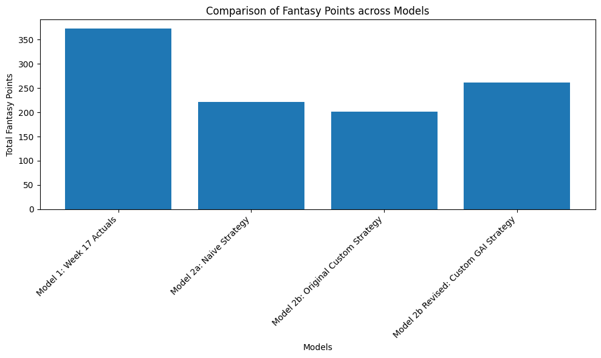

```python
# Creating a graph to visualize the total fantasy points across all the optimization problems
plt.figure(figsize=(10, 6))
plt.bar(model_fantasy_points.keys(), model_fantasy_points.values())
plt.xlabel("Models")
plt.ylabel("Total Fantasy Points")
plt.title("Comparison of Fantasy Points across Models")
plt.xticks(rotation=45, ha="right")  # Rotate x-axis labels for better readability
plt.tight_layout() # Adjust layout to prevent labels from overlapping
plt.show()
```

## Summary:

While none of these models replicated the actual optimal lineup, the AI-assisted method performed the best. This suggests that ranking players by their historical fantasy points is a more effective approach than selecting based on isolated statistics.